# Analysis of Health and Economic Consequences of Storm Events

**Synopsis:** This is an analysis that uses the U.S. National Oceanic and Atmospheric Administration’s (NOAA) storm database to attempt to answer the following two questions

1. Across the United States, which types of events (as indicated in the EVTYPE variable) are most harmful with respect to population health?
2. Across the United States, which types of events have the greatest economic consequences?

# Data Processing

Load required libraries

```r
library(dplyr)
library(lubridate)
```

```r
library(stringr)
library(ggplot2)
library(cowplot)
library(forcats)
library(tidyverse)
```

Read the data into R and run `str()` to get a sense of the data.

```r
storm <- read.csv("repdata_data_StormData.csv")
str(storm)
```

```
## 'data.frame':    902297 obs. of  37 variables:
##  $ STATE__   : num  1 1 1 1 1 1 1 1 1 1 ...
##  $ BGN_DATE  : chr  "4/18/1950 0:00:00" "4/18/1950 0:00:00" "2/20/1951 0:00:00" "6/8/1951 0:00:00" ...
##  $ BGN_TIME  : chr  "0130" "0145" "1600" "0900" ...
##  $ TIME_ZONE : chr  "CST" "CST" "CST" "CST" ...
##  $ COUNTY    : num  97 3 57 89 43 77 9 123 125 57 ...
##  $ COUNTYNAME: chr  "MOBILE" "BALDWIN" "FAYETTE" "MADISON" ...
##  $ STATE     : chr  "AL" "AL" "AL" "AL" ...
##  $ EVTYPE    : chr  "TORNADO" "TORNADO" "TORNADO" "TORNADO" ...
##  $ BGN_RANGE : num  0 0 0 0 0 0 0 0 0 0 ...
##  $ BGN_AZI   : chr  "" "" "" "" ...
##  $ BGN_LOCATI: chr  "" "" "" "" ...
##  $ END_DATE  : chr  "" "" "" "" ...
##  $ END_TIME  : chr  "" "" "" "" ...
##  $ COUNTY_END: num  0 0 0 0 0 0 0 0 0 0 ...
```

[output cut: 23 more lines]

We can see that there is already a `BGN_TIME` column, so we can remove the “0:00:00” part from the `BGN_DATE` column. We can do the same thing for `END_DATE` as well. Also create a new column containing just the year so we can make a time-series plot later.

```r
storm = storm %>%
  ### Extract only the first part of the string for BGN_DATE and END_DATE columns
  mutate(
    BGN_DATE = str_extract(BGN_DATE, pattern = "^[^ ]+"),
    END_DATE = str_extract(END_DATE, pattern = "^[^ ]+")
         ) %>%
  ### Convert date columns to date class and create new column containing the year
  mutate(
    BGN_DATE = mdy(BGN_DATE),
    END_DATE = mdy(END_DATE),
    BGN_YEAR = year(BGN_DATE)
    )
```

For the character variables, we will convert any empty strings to `NA`. Also, we will convert `EVTYPE` to a factor variable since that will be used later in our plots.

```r
storm = storm %>%
  mutate(
    across(where(is.character), ~na_if(., "")), ### convert empty strings to NA
    EVTYPE = as.factor(EVTYPE) ### convert EVTYPE to factor
  )
```

Now lets take a closer look at the `PROPDMGEXP` and `CROPDMGEXP` variables

```r
levels(as.factor(storm$PROPDMGEXP))
```

```
##  [1] "-" "?" "+" "0" "1" "2" "3" "4" "5" "6" "7" "8" "B" "h" "H" "K" "m" "M"
```

```r
levels(as.factor(storm$CROPDMGEXP))
```

```
## [1] "?" "0" "2" "B" "k" "K" "m" "M"
```

It seems that these are units including units for hundreds, thousands, millions, and billions. I will recode the `PROPDMG` and `CROPDMG` to be in dollars instead

```r
storm = storm %>%
  mutate(
    PROPDMGEXP = tolower(PROPDMGEXP), ### convert to lower case
    PROPDMGEXP = case_when(
      PROPDMGEXP == "h" ~ "2", ### hundreds
      PROPDMGEXP == "k" ~ "3", ### thousands
      PROPDMGEXP == "m" ~ "6", ### millions
      PROPDMGEXP == "b" ~ "9", ### billions
      TRUE ~ PROPDMGEXP
    )
  ) %>%
  mutate(
    CROPDMGEXP = tolower(CROPDMGEXP), ### convert to lower case
    CROPDMGEXP = case_when(
      CROPDMGEXP == "h" ~ "2", ### hundreds
      CROPDMGEXP == "k" ~ "3", ### thousands
      CROPDMGEXP == "m" ~ "6", ### millions
      CROPDMGEXP == "b" ~ "9", ### billions
      TRUE ~ CROPDMGEXP
    )
  ) %>%
  mutate(
    PROPDMGEXP = as.numeric(PROPDMGEXP), ### convert to numeric
    CROPDMGEXP = as.numeric(CROPDMGEXP)  ### convert to numeric
  ) %>%
  filter(!is.na(PROPDMGEXP)) %>% ### filter out any rows with missing exponents
  filter(!is.na(CROPDMGEXP)) %>% ### filter out any rows with missing exponents
  mutate(
    PROPDMG = PROPDMG * 10^PROPDMGEXP, ### recode PROPDMG and CROPDMG in dollars
    CROPDMG = CROPDMG * 10^CROPDMGEXP
         )
```

Lets take a closer look at the `EVTYPE` variable

```r
levels(as.factor(storm$EVTYPE))
```

```
##   [1] "   HIGH SURF ADVISORY"          " COASTAL FLOOD"
##   [3] " FLASH FLOOD"                   " LIGHTNING"
##   [5] " TSTM WIND"                     " TSTM WIND (G45)"
##   [7] " WATERSPOUT"                    " WIND"
##   [9] "?"                              "ABNORMAL WARMTH"
##  [11] "ABNORMALLY DRY"                 "ABNORMALLY WET"
##  [13] "ACCUMULATED SNOWFALL"           "AGRICULTURAL FREEZE"
##  [15] "APACHE COUNTY"                  "ASTRONOMICAL HIGH TIDE"
##  [17] "ASTRONOMICAL LOW TIDE"          "AVALANCE"
##  [19] "AVALANCHE"                      "BEACH EROSIN"
##  [21] "Beach Erosion"                  "BEACH EROSION"
##  [23] "BEACH EROSION/COASTAL FLOOD"    "BEACH FLOOD"
##  [25] "BELOW NORMAL PRECIPITATION"     "BITTER WIND CHILL"
##  [27] "BITTER WIND CHILL TEMPERATURES" "Black Ice"
##  [29] "BLACK ICE"                      "BLIZZARD"
```

[output cut: 478 more lines]

We can see that there are some repeated `EVTYPE`s due to case sensitivity, and some inconsistent naming conventions. We will convert everything to lower case, then use `stringr` to identify `EVTYPE`s that are the same type of weather event and combine them into a consistent naming convention.

```r
### Convert everything to lower case
storm = storm %>%
  mutate(
    EVTYPE = tolower(EVTYPE)
  )

### Identify EVTYPEs that are the same and recode them to have a consistent naming convention
storm <- storm %>%
  mutate(EVTYPE = case_when(
    str_detect(EVTYPE, "hurricane") ~ "hurricane",
    str_detect(EVTYPE, "tropical storm|tropical depression") ~ "tropical storm",
    str_detect(EVTYPE, "flood|fld") ~ "flood",
    str_detect(EVTYPE, "thunderstorm") ~ "thunderstorm",
    str_detect(EVTYPE, "fire") ~ "fire",
    str_detect(EVTYPE, "tornado") ~ "tornado",
    str_detect(EVTYPE, "rain") ~ "rain",
    str_detect(EVTYPE, "heat") ~ "heat",
    str_detect(EVTYPE, "wind|funnel cloud|gustnado") ~ "wind",
    str_detect(EVTYPE, "wintry mix") ~ "wintry mix",  # Explicitly categorize it
    str_detect(EVTYPE, "ice|freez|winter|snow|blizzard|cold|icy") ~ "cold",
    str_detect(EVTYPE, "hail|sleet") ~ "hail",
    str_detect(EVTYPE, "surf|tsunami|storm surge|waterspout|rip current|seiche") ~ "surf",
    str_detect(EVTYPE, "fog") ~ "fog",
    str_detect(EVTYPE, "dust") ~ "dust",
    TRUE ~ EVTYPE  # Retain original if no match
  ))
```

# Results

To answer question 1:

> 1. Across the United States, which types of events (as indicated in the `EVTYPE` variable) are most harmful with respect to population health?

We can compare `EVTYPE` against injuries and fatalities.

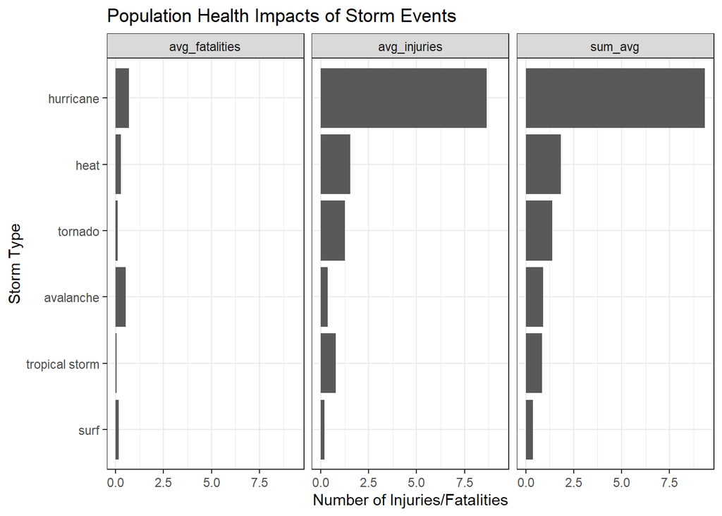

```r
### Storm events with the top 5 highest average injuries
injuries <- storm %>%
  group_by(EVTYPE) %>%
  summarise(
    avg_injuries = mean(INJURIES, na.rm = TRUE)
  ) %>%
  arrange(desc(avg_injuries)) %>%
  mutate(EVTYPE = fct_reorder(EVTYPE, avg_injuries)) %>%
  head(5)

### Storm events with the top 5 highest average fatalities
fatalities <- storm %>%
  group_by(EVTYPE) %>%
  summarise(
    avg_fatalities = mean(FATALITIES, na.rm = TRUE)
  ) %>%
  arrange(desc(avg_fatalities)) %>%
  mutate(EVTYPE = fct_reorder(EVTYPE, avg_fatalities)) %>%
  head(5)

### Take the set union of the top 5 storm events from the two categories above (average injuries and average fatalities)
combined <- unique(union(injuries$EVTYPE, fatalities$EVTYPE))

### Filter `s` dataframe for the combined storm events taken above, then calculate the avg injuries, fatalities, and the sum of those (which I call harm_index) and arrange descending by harm_index
combined_df <- storm %>%
  filter(EVTYPE %in% combined) %>%
  group_by(EVTYPE) %>%
  summarise(
    avg_injuries = mean(INJURIES, na.rm = TRUE),
    avg_fatalities = mean(FATALITIES, na.rm = TRUE),
    sum_avg = avg_injuries + avg_fatalities
  ) %>%
  arrange(desc(sum_avg)) %>%
  mutate(EVTYPE = fct_reorder(EVTYPE, sum_avg))

### Pivot to a longer format
combined_df_longer = combined_df %>%
  pivot_longer(
    cols = avg_injuries:sum_avg,
    names_to = "harm_type",
    values_to = "count"
  )

### Plot bar charts and facet by harm_type to see bar charts for avg injuries, fatalities, and harm_index, and how they compare
ggplot(combined_df_longer, aes(x = EVTYPE, y = count)) +
  geom_col() +
  theme_bw() +
  labs(
    title = "Population Health Impacts of Storm Events",
    x = "Storm Type",
    y = "Number of Injuries/Fatalities"
  ) +
  coord_flip() +
  facet_wrap(~harm_type)
```

Hurricanes is at the top spot for both average injuries and average fatalities, although it has a much larger lead compared to the others for average injuries. Heat, tornado, and tropical storm are the runners up when it comes to average injuries, whereas avalanche, heat, and surf are runners up when it comes to average fatalities. Avalaches stand out because they are the only one that have a higher number of fatalities than injuries on average.

To answer question 2:

> 2. Across the United States, which types of events have the greatest economic consequences?

We can compare `EVTYPE` against property and crop damage.

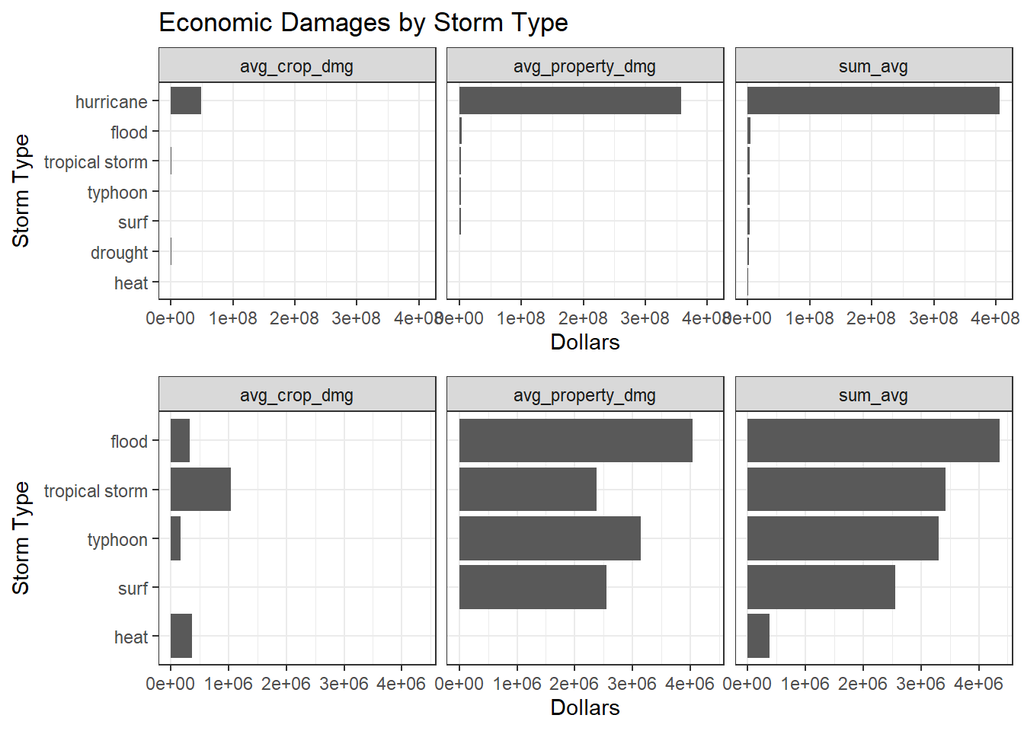

```r
### Top 5 property damage by EVTYPE
prop_dmg <- storm %>%
  group_by(EVTYPE) %>%
  summarise(avg_property_dmg = mean(PROPDMG, na.rm = TRUE)) %>%
  arrange(desc(avg_property_dmg)) %>%
  mutate(EVTYPE = fct_reorder(EVTYPE, avg_property_dmg)) %>%
  head(5)

### Top 5 crop damage by EVTYPE
crop_dmg <- storm %>%
  group_by(EVTYPE) %>%
  summarise(
    avg_crop_dmg = mean(CROPDMG, na.rm = TRUE)
  ) %>%
  arrange(desc(avg_crop_dmg)) %>%
  mutate(EVTYPE = fct_reorder(EVTYPE, avg_crop_dmg)) %>%
  head(5)

### Get union of top 5 EVTYPEs by Property damage and Crop damage
combined <- unique(union(prop_dmg$EVTYPE, crop_dmg$EVTYPE))

### Filter `s` dataframe for the combined storm events taken above, then calculate the avg property damage, crop damage, and the sum of those (which I call sum_avg) and arrange descending by sum_avg
combined_df <- storm %>%
  filter(EVTYPE %in% combined) %>%
  group_by(EVTYPE) %>%
  summarise(
    avg_property_dmg = mean(PROPDMG, na.rm = TRUE),
    avg_crop_dmg = mean(CROPDMG, na.rm = TRUE),
    sum_avg = avg_property_dmg + avg_crop_dmg
  ) %>%
  arrange(desc(sum_avg)) %>%
  mutate(EVTYPE = fct_reorder(EVTYPE, sum_avg))

### Pivot longer
combined_df_longer = combined_df %>%
  pivot_longer(
    cols = avg_property_dmg:sum_avg,
    names_to = "damage_type",
    values_to = "dollars"
  )

### Plot economic damage effects for property, crops, and sum(property, crops)
p1 <- ggplot(combined_df_longer, aes(x = EVTYPE, y = dollars)) +
  geom_bar(stat = "identity") +
  labs(
    title = "Economic Damages by Storm Type",
    x = "Storm Type",
    y = "Dollars"
  ) +
  coord_flip() +
  theme_bw() +
  facet_wrap(~damage_type)

### Remove "hurricane" because it is an outlier in order to see the other storm types better. Also remove "drought" since it is so small it does not appear on the plot
combined_df_longer_no_h <- combined_df_longer %>%
  filter(EVTYPE != "hurricane" & EVTYPE != "drought")

### Plot economic damage again with outliers removed, to see the other storm types better
p2 <- ggplot(combined_df_longer_no_h, aes(x = EVTYPE, y = dollars)) +
  geom_bar(stat = "identity") +
    labs(
    x = "Storm Type",
    y = "Dollars"
  ) +
  coord_flip() +
  theme_bw() +
  facet_wrap(~damage_type)

### Display the plots in a plot grid
plot_grid(p1, p2, nrow = 2)
```

We might also be interested in seeing the overall trend over time of population health effects and economic damages from all storm events combined. I have plotted that below.

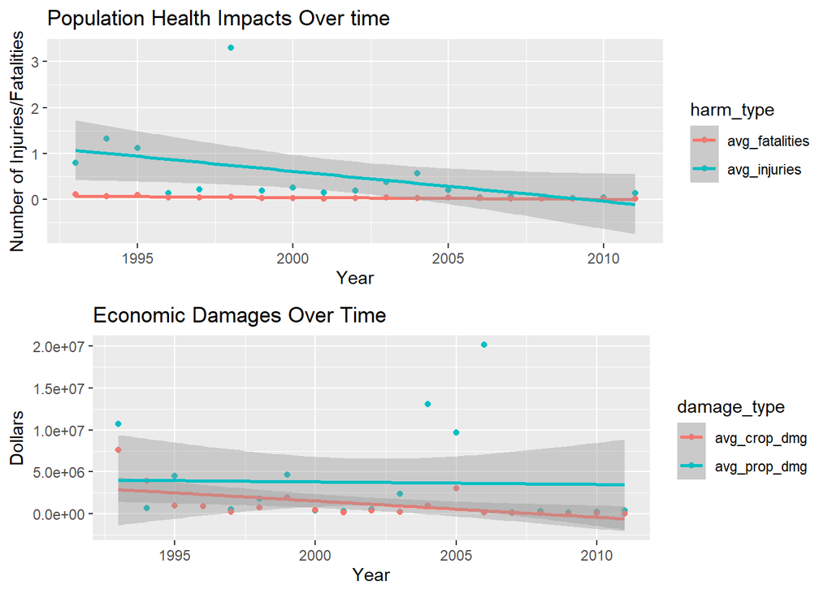

```r
### Average property damage and crop damage by year
economic_dmg_time <- storm %>%
  group_by(BGN_YEAR) %>%
  summarise(
    avg_prop_dmg = mean(PROPDMG, na.rm = TRUE),
    avg_crop_dmg = mean(CROPDMG, na.rm = TRUE),
  )

### pivot longer
economic_dmg_time <- economic_dmg_time %>%
  pivot_longer(
    cols = c(avg_prop_dmg, avg_crop_dmg),
    names_to = "damage_type",
    values_to = "dollars"
  )

### Plot economic damage over time for all storm types combined
p1 <- ggplot(economic_dmg_time,
       aes(x = BGN_YEAR, y = dollars, colour = damage_type)) +
  geom_point() +
  geom_smooth(method = "lm") +
  labs(
    title = "Economic Damages Over Time",
    x = "Year",
    y = "Dollars"
  )

### Average injuries and fatalities by year
harm_time <- storm %>%
  group_by(BGN_YEAR) %>%
  summarise(
    avg_injuries = mean(INJURIES, na.rm = TRUE),
    avg_fatalities = mean(FATALITIES, na.rm = TRUE),
  )

### Pivot longer
harm_time <- harm_time %>%
  pivot_longer(
    cols = c(avg_injuries, avg_fatalities),
    names_to = "harm_type",
    values_to = "count"
  )

### Plot population health effects over time for all storm types combined
p2 <- ggplot(harm_time,
       aes(x = BGN_YEAR, y = count, colour = harm_type)) +
  geom_point() +
  geom_smooth(method = "lm") +
  labs(
    title = "Population Health Impacts Over time",
    x = "Year",
    y = "Number of Injuries/Fatalities"
  )

### Display the plots in a grid
plot_grid(p2, p1, nrow = 2)
```

In terms of population health effects, the number of injuries for all storm events on average has fallen from about 1 to about 0 over the years, whereas the number of fatalities on average has remained close to 0. There is an especially high instance of average injury rate at about 1998. As far as economic damages, there is a very slight decrease in property damage from storms over time. There are a couple of years around 2005 with high average property damage from storm events. Crop damages have decreased more over the years.